[figure not shown]

📈 Portfolio Showcase #1 • Econometric Regression

# Egészségbiztosítási Költségek OLS Regressziós Elemzése

End-to-end ökonometriai és adatelemzési esettanulmány: a költségeket generáló kockázati tényezők feltárása, spearman-féle rangkorreláció, multikollinearitás-szűrés (VIF), interakciós modellezés, automatizált hátrafelé elimináció (Backward Elimination) és HC3 robusztus hibadiagnosztika.

[🏠 Portfólió Főoldal](https://kovacsimi.github.io/) [GitHub Repository (Teljes Kód & Elemzés)](https://github.com/KovacsImi/Linear-Regression) [K Kaggle Adatforrás: mirichoi0218/insurance/data](https://www.kaggle.com/datasets/mirichoi0218/insurance/data)

Python 3.10+ statsmodels scikit-learn seaborn & matplotlib Kovács Imre (IK)

Magyarázóerő (R²)

82.20%

+7.2 pp növekedés az interakcióval

Korrigált R²

82.12%

Büntetett illeszkedési mutató

Modellhiba (RMSE)

$5,107

Átlagos négyzetes hiba

Abszolút Hiba (MAE)

$3,137

Átlagos abszolút eltérés

Mintanagyság (n)

1 337

1 duplikátum szűrve, 0 hiányzó

⚡ Interaktív Elemzési Eszköz

## Élő OLS Biztosítási Díjbecslő Szimulátor

Próbáld ki a megbecsült regressziós egyenletet valós időben! Állítsd be az ügyfél életkorát, testtömegindexét, gyermekeinek számát és dohányzási státuszát, hogy lásd a várható éves egészségügyi költséget és a dohányzás sokszorozó hatását.

Életkor (age): 35 év

Testtömegindex (BMI): 28.0 kg/m²

Eltartott gyermekek száma: 1 gyermek

Dohányzik a biztosított?

Lakóhelyi Régió:

Becsült Éves Biztosítási Díj (charges)

Alap tengelymetszet (Const):-$7 091

Életkor költsége (35 × $261):+$9 149

BMI alaphatás (28 × $163):+$4 559

Gyermekek költsége:+$488

Régió korrekció:-$942

Dohányzás × BMI interakció: $0

00

## Az Egészségbiztosítási Költségek Elemzésének Üzleti és Egészségügyi Jelentősége

A modern egészségbiztosítási és ellátórendszerekben a jövőbeli kárkifizetések előrejelzése és a költségmeghatározó faktorok számszerűsítése alapvető pénzügyi és orvos-szakmai követelmény. Az alulárazás csődhöz és likviditási válsághoz vezet, míg a túlárazás elveszíti az alacsony kockázatú, egészséges ügyfeleket (negatív szelekció).

🎯 1. Kockázatalapú Díjszabás (Actuarial Pricing)

A biztosítási prémiumok kalkulációja nem alapulhat pusztán átlagokon, mivel az egészségügyi kiadások szélsőségesen aszimmetrikusak: a biztosítottak egy kis része felelős az összköltségek döntő többségéért. Egy megbízható ökonometriai modell lehetővé teszi a kockázatarányos díjszabást, garantálja a biztosító likviditását és a tőkekövetelmények stabil teljesülését.

💡 2. Módosítható vs. Nem Módosítható Rizikófaktorok

Az elemzés világos határvonalat húz a biológiailag determinált (nem befolyásolható) tényezők — mint az **életkor** és a **nem** — valamint az életmódbeli (módosítható) rizikófaktorok — mint a **dohányzás** és a **testtömegindex (BMI)** — között. Ez a megkülönböztetés teremti meg az alapját a célzott egészségmegőrző és prevenciós programoknak.

⚠️ A Kulcsfelismerés: A Dohányzás és az Elhízás Költségsokszorozó Szinergiája

A hagyományos leíró modellek gyakran különálló, additív faktorként tekintenek a dohányzásra és a túlsúlyra. Jelen elemzésünk bizonyítja, hogy e két tényező között **szignifikáns interakciós kapcsolat** áll fenn: a dohányzás nem csupán fix összegű költségnövekedést okoz, hanem **többszörösére gyorsítja a testsúly növekedéséből fakadó ellátási kiadásokat**. Egy dohányzó elhízott egyén költségkockázata exponenciálisan magasabb, mint a két tényező önálló hatásának összege!

### Az Adatbázis Változóinak Strukturált Ismertetése

| Változó | Megnevezés | Típus | Mértékegység | Szerep |
| --- | --- | --- | --- | --- |
| `age` | Életkor | Numerikus (egész) | Év (18 - 64) | Magyarázó (biológiai öregedés kockázata) |
| `sex` | Biológiai nem | Kategorikus | male / female | Magyarázó (One-Hot kódolt dummy) |
| `bmi` | Testtömegindex | Numerikus (folytonos) | kg/m² (15.96 - 53.13) | Magyarázó (túlsúly és elhízás kockázata) |
| `children` | Gyermekek száma | Numerikus (diszkrét) | Fő (0 - 5) | Magyarázó (családméret / eltartottak) |
| `smoker` | Dohányzás | Kategorikus | yes / no | Kulcs magyarázó és moderáló faktor |
| `region` | Lakóhelyi régió | Kategorikus | 4 USA régió | Földrajzi / ellátási költségkülönbségek |
| `charges` | Biztosítási költség | Numerikus (folytonos) | USD ($1 121 - $63 770) | **CÉLVÁLTOZÓ (y)** |

01

## 1. Adatbázis Beolvasása és Adatminőség-ellenőrzés

Az elemzés alapjául szolgáló hivatalos adatkészlet elérhető a Kaggle felületén: https://www.kaggle.com/datasets/mirichoi0218/insurance/data . Az adatállományt közvetlenül a `kagglehub` csomagon keresztül töltöttük be (`mirichoi0218/insurance`, `insurance.csv`). Az adatminőség ellenőrzése során felmértük a sor- és oszlopméretet, a duplikációkat és a hiányzó értékeket.

**1. Fejezet Kódjának Megtekintése (Adatbetöltés és Minőségellenőrzés)**

```python
# 1.0 - Adat beolvasas Kaggle-rol (https://www.kaggle.com/datasets/mirichoi0218/insurance/data)
import kagglehub
from kagglehub import KaggleDatasetAdapter

df = kagglehub.load_dataset(
    KaggleDatasetAdapter.PANDAS,
    "mirichoi0218/insurance",
    "insurance.csv",
)

# 1.1 - Duplikatumok szurese
num_duplicates = df.duplicated().sum()
if num_duplicates > 0:
    df = df.drop_duplicates().reset_index(drop=True)

# 1.2 - Hianyzo ertekek ellenorzese
missing_df = pd.DataFrame({
    "Hianyzo ertekek szama": df.isnull().sum(),
    "Hianyzo ertekek aranya (%)": (df.isnull().sum() / len(df) * 100).round(2)
})
```

🔍 Adatminőség Eredményei:

- **Eredeti sorméret:** 1 338 megfigyelés, 7 változó.
- **Duplikátum szűrés:** Pontosan **1 darab duplikált rekord** került azonosításra (egy 19 éves, délnyugati, nem dohányzó férfi azonos költséggel). A duplikátumot eltávolítottuk.
- **Tisztított mintanagyság:** **1 337 megfigyelés**.
- **Hiányzó adatok:** Az adatbázisban **0 darab hiányzó (null) érték** található, a mátrix teljes.
- **Hivatalos forrás:** kaggle.com/datasets/mirichoi0218/insurance/data

| Változó | Hianyzo ertekek szama | Hianyzo ertekek aranya (%) |
| --- | --- | --- |
| age | 0 | 0 |
| sex | 0 | 0 |
| bmi | 0 | 0 |
| children | 0 | 0 |
| smoker | 0 | 0 |
| region | 0 | 0 |
| charges | 0 | 0 |

02

## 2. Feltáró Adatelemzés (EDA) – Eloszlások és Gyakoriságok

A leíró statisztikai elemzés során feltérképeztük az egyes változók centrális tendenciáit, szóródását, aszimmetriáját (skewness), és azonosítottuk a potenciális kiugró értékeket (outliereket).

**2. Fejezet Kódjának Megtekintése (EDA és Eloszlás-ábrák)**

```python
# Numerikus valtozok eloszlasa (Hisztogram es Boxplot)
numeric_cols = df.select_dtypes(include=np.number).columns.tolist()
for col in numeric_cols:
    fig, axes = plt.subplots(1, 2, figsize=(14, 5))
    if col == "children":
        # Diszkret valtozo: pontos egesz ertekeknel, KDE trendvonal nelkul
        sns.histplot(df[col], discrete=True, kde=False, color="steelblue", ax=axes[0],
                     edgecolor="white", linewidth=0.8, shrink=0.85)
        axes[0].set_title(f"'{col}' eloszlasa (Diszkret hisztogram)")
        axes[0].set_xticks([0, 1, 2, 3, 4, 5])
    else:
        sns.histplot(df[col], kde=True, bins=30, color="steelblue", ax=axes[0],
                     edgecolor="white", linewidth=0.5)
        axes[0].set_title(f"'{col}' eloszlasa (Hisztogram + KDE)")
    sns.boxplot(x=df[col], color="lightcoral", ax=axes[1])
    save_and_show(fig, f"dist_{col}")

# Kategorikus valtozok gyakorisaga (Countplot)
categorical_cols = df.select_dtypes(include="object").columns.tolist()
for col in categorical_cols:
    fig, ax = plt.subplots(figsize=(8, 5))
    sns.countplot(x=df[col], palette="viridis", ax=ax)
    save_and_show(fig, f"count_{col}")
```

### Numerikus Változók Leíró Statisztikái (n = 1 337)

| Statisztika | age | bmi | children | charges |
| --- | --- | --- | --- | --- |
| count | 1 337 | 1 337 | 1 337 | 1 337 |
| mean | 39,22 | 30,66 | 1,10 | 13 279,12 |
| std | 14,04 | 6,10 | 1,21 | 12 110,36 |
| min | 18 | 15,96 | 0 | 1 121,87 |
| 25% | 27 | 26,29 | 0 | 4 746,34 |
| 50% | 39 | 30,40 | 1 | 9 386,16 |
| 75% | 51 | 34,70 | 2 | 16 657,72 |
| max | 64 | 53,13 | 5 | 63 770,43 |

👤 Életkor (age)

Átlag: **39.2 év**, medián: **39.0 év** (18–64 év). Kiegyensúlyozott, közel egyenletes eloszlás, outlierek nélkül.

⚖️ Testtömegindex (bmi)

Átlag: **30.66 kg/m²**, medián: **30.40 kg/m²**. Szimmetrikus Gauss-görbe, a minta több mint fele a túlsúlyos / elhízott kategóriába esik.

👶 Gyermekek száma (children)

Átlag: **1.1 fő** (0–5 gyermek). A biztosítottak 42.9%-ának nincs gyermeke, a 4-5 gyermekes családok ritkák (3.2%).

💵 Költségek (charges)

Átlag: **$13 279**, medián: **$9 386**. Erősen jobbra ferde eloszlás, jelentős jobboldali farokkal ($63 770-ig).

📊 ÁBRA 1. Ábra: Életkor (age) eloszlása és dobozábrája

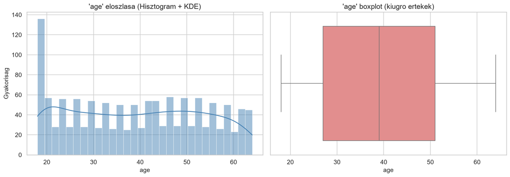

🔍 Nagyítás kattintással

**Magyarázat:** Az életkor eloszlása egyenletes (uniform jellegű) a 18 és 64 év közötti tartományban, a 18-19 éves korcsoportban enyhe felülreprezentáltsággal. A dobozábrán az alsó- és felső határoló pontok között helyezkedik el a teljes minta, kiugró érték nincs.

📊 ÁBRA 2. Ábra: Testtömegindex (bmi) eloszlása és dobozábrája

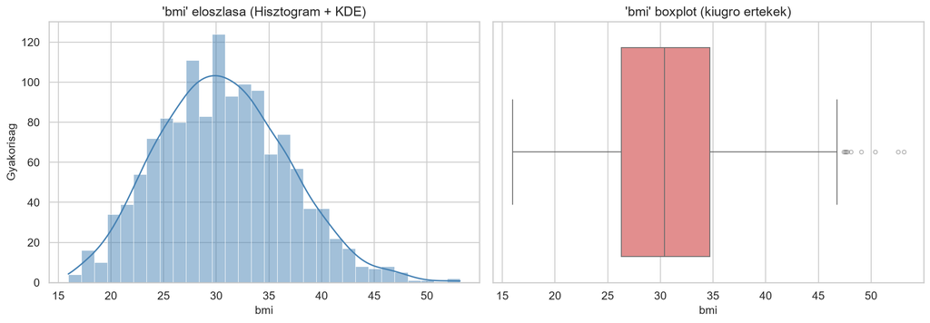

🔍 Nagyítás kattintással

**Magyarázat:** A testtömegindex (BMI) szép szimmetrikus haranggörbét alkot, átlaga 30.66 kg/m², mediánja 30.40 kg/m², ami a WHO besorolás szerint már az I. fokú elhízás kategóriája. A dobozábra alsó- és felső határoló pontjait vizsgálva, a felső határoló ponton túl néhány extrém magas érték (45-53 kg/m²) látható.

📊 ÁBRA 3. Ábra: Gyermekek száma (children) diszkrét eloszlása és dobozábrája

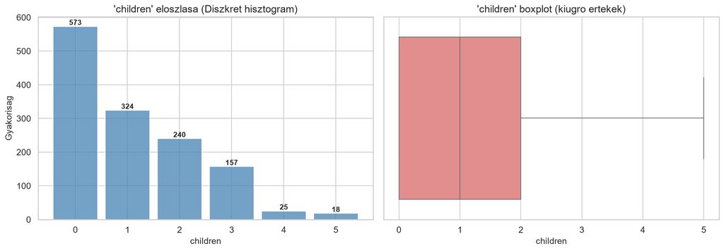

🔍 Nagyítás kattintással

📊 ÁBRA 4. Ábra: Biztosítási költségek (charges) eloszlása és dobozábrája

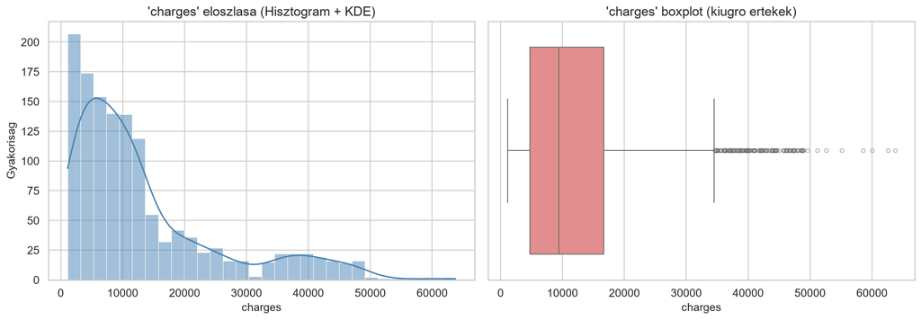

🔍 Nagyítás kattintással

**Magyarázat:** A célváltozó (charges) rendkívül erősen jobbra ferde eloszlást mutat. Az átlag ($13 279) jelentősen meghaladja a mediánt ($9 386). A biztosítottak zöme $2 000 és $12 000 közötti költséget generál, de a felső határoló ponton túl a hosszú jobboldali farok egészen $63 770-ig nyúlik.

📊 ÁBRA 5. Ábra: Nemek aránya (sex)

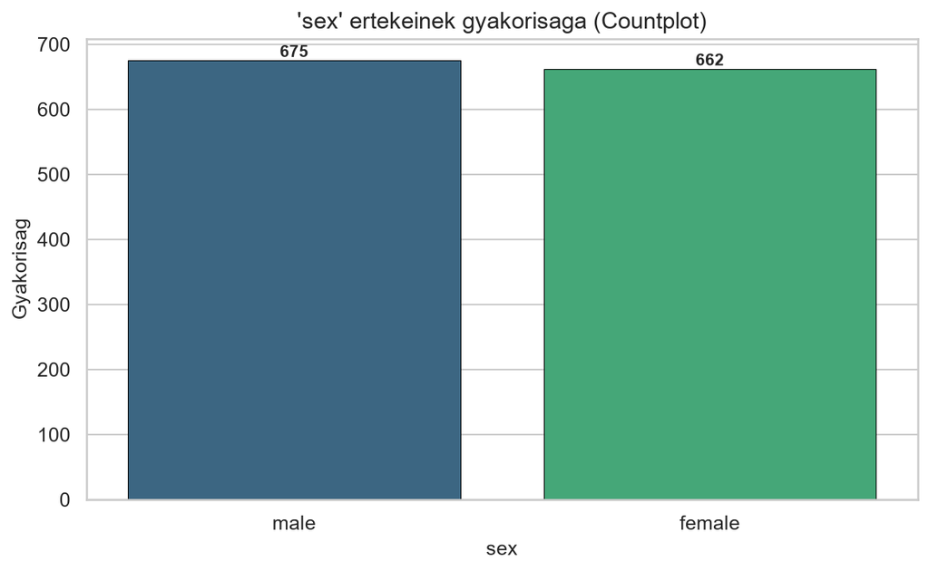

🔍 Nagyítás kattintással

**Magyarázat:** A nemek eloszlása szinte tökéletesen kiegyensúlyozott: 675 férfi (50.5%) és 662 nő (49.5%) szerepel a mintában.

📊 ÁBRA 6. Ábra: Dohányzók megoszlása (smoker)

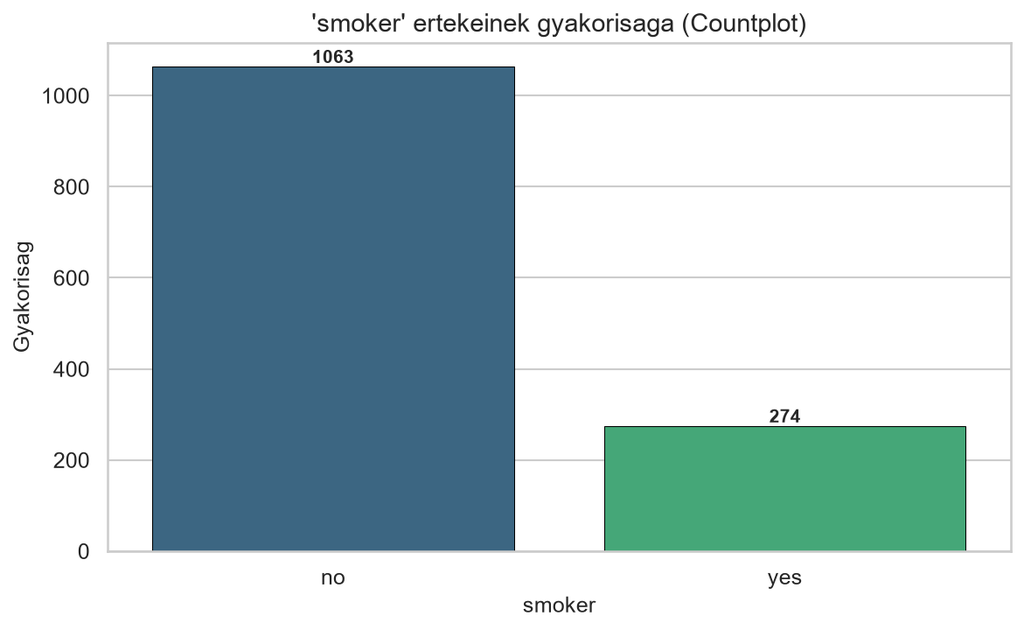

🔍 Nagyítás kattintással

**Magyarázat:** A dohányzók aránya 20.5% (274 fő), míg a nem dohányzóké 79.5% (1 063 fő). Ez az arány hűen reprezentálja a fejlett társadalmak dohányzási rátáját.

📊 ÁBRA 7. Ábra: Lakóhelyi régiók megoszlása (region)

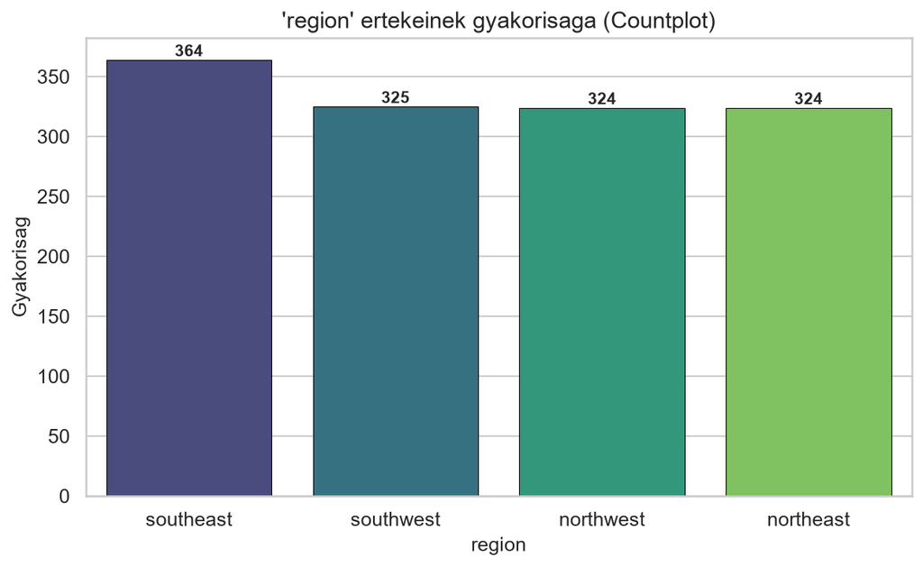

🔍 Nagyítás kattintással

**Magyarázat:** A négy amerikai földrajzi régió megoszlása rendkívül kiegyenlített: délkeleten 364 fő él, míg az északnyugati, délnyugati és északkeleti régiókban 324-325 fő található.

03

## 3. Célváltozó (Charges) vs. Magyarázó Változók – A Dohányzás Moderáló Szerepe

A magyarázó változók és a biztosítási költségek kapcsolatát színezett pontdiagramokon (`hue='smoker'`) vizsgáltuk. Ez a lépés tárta fel az egész adathalmaz legfontosabb strukturális sajátosságát.

**3. Fejezet Kódjának Megtekintése (Scatter, Boxplot és Stripplot)**

```python
# 2.6a: charges vs age | charges vs bmi (hue='smoker')
fig = plt.figure(figsize=(14, 6))
ax1 = fig.add_subplot(121)
sns.scatterplot(x="age", y="charges", data=df, palette="magma", hue="smoker", ax=ax1)

ax2 = fig.add_subplot(122)
sns.scatterplot(x="bmi", y="charges", data=df, palette="viridis", hue="smoker", ax=ax2)
save_and_show(fig, "scatter_age_bmi_vs_charges")

# 2.6b: charges vs children | charges vs smoker (boxplot)
fig = plt.figure(figsize=(14, 6))
ax3 = fig.add_subplot(121)
sns.scatterplot(x="children", y="charges", data=df, palette="coolwarm", hue="smoker", ax=ax3)

ax4 = fig.add_subplot(122)
sns.boxplot(x="smoker", y="charges", data=df, palette="Set2", ax=ax4)
save_and_show(fig, "scatter_children_smoker_vs_charges")
```

📊 ÁBRA 8. Ábra: Költségek az életkor és a BMI függvényében (dohányzás szerinti színezéssel)

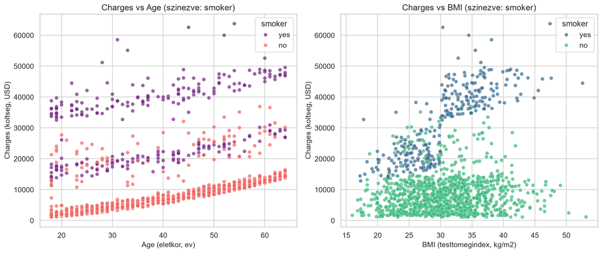

🔍 Nagyítás kattintással

**Magyarázat:** Bal oldal: Életkor vs Költség. Három élesen elkülönülő sáv rajzolódik ki, és mindháromban lineárisan nő a költség a korral, de a legfelső ($30k-$60k) sávot kizárólag a dohányzók uralják! Jobb oldal: BMI vs Költség. A döntő ábra! Nem dohányzóknál a BMI növekedése alig növeli a díjat. Dohányzóknál azonban a 30-as BMI felett a költségek hirtelen a $30 000 - $45 000 tartományba ugranak!

⚡ Strukturális Áttörés: A 30-as BMI Küszöbérték-Effektus

A 8. ábra jobb paneljén látható, hogy míg a nem dohányzóknál a BMI enyhe lejtésű egyenest követ ($2 000 – $12 000), addig a dohányzóknál a **30-as BMI (orvosi elhízási küszöb)** egy valódi költségrobbanási pont: a költségek ugrásszerűen $30 000 fölé szöknek. Ez a vizuális bizonyíték teszi elengedhetetlenné a `bmi * smoker_yes` interakciós tag beépítését a regressziós modellbe.

📊 ÁBRA 9. Ábra: Költségek a gyermekek száma és a dohányzás szerint

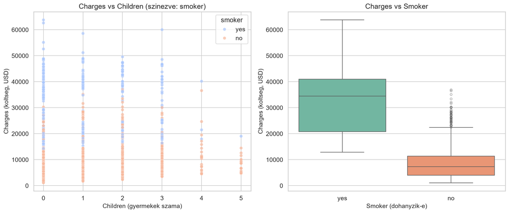

🔍 Nagyítás kattintással

📊 ÁBRA 10. Ábra: Költségek a biológiai nem és a régió szerint (dohányzás szerinti színezéssel)

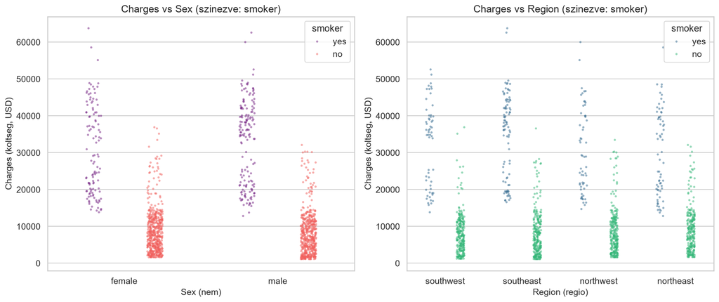

🔍 Nagyítás kattintással

**Magyarázat:** A nemek és a régiók szerinti bontásban a pontok eloszlása szinte azonos. Önmagában sem a nem, sem a földrajzi elhelyezkedés nem hoz létre markáns költségkülönbséget; a csoportokon belüli szóródás motorja mindenütt a dohányzási státusz.

04

## 4. Adatelőkészítés, One-Hot Encoding és Interakciós Tagok Képzése

A kategorikus oszlopokat dummy kódolással alakítottuk át (`drop_first=True` a Dummy Variable Trap elkerülésére), majd származtatott változóként képeztük a `bmi_x_smoker` és `age_x_smoker` interakciós tagokat. Ezt követően kiszámítottuk a Spearman-féle rangkorrelációs mátrixot.

**4. Fejezet Kódjának Megtekintése (Dummy kódolás, Interakciók és Spearman Hőtérkép)**

```python
# One-Hot Encoding
df_encoded = pd.get_dummies(df, columns=categorical_cols, drop_first=True, dtype=float)

# Interakcios tagok kepzese
df_encoded["bmi_x_smoker"] = df_encoded["bmi"] * df_encoded["smoker_yes"]
df_encoded["age_x_smoker"] = df_encoded["age"] * df_encoded["smoker_yes"]

# Spearman rangkorrelacios matrix es hoterkep
spearman_corr = df_encoded.corr(method="spearman")
mask = np.triu(np.ones_like(spearman_corr, dtype=bool))
sns.heatmap(spearman_corr, annot=True, fmt=".2f", cmap="coolwarm", mask=mask)
save_and_show(fig_hm, "spearman_heatmap")
```

📊 ÁBRA 11. Ábra: Spearman-féle Rangkorrelációs Hőtérkép

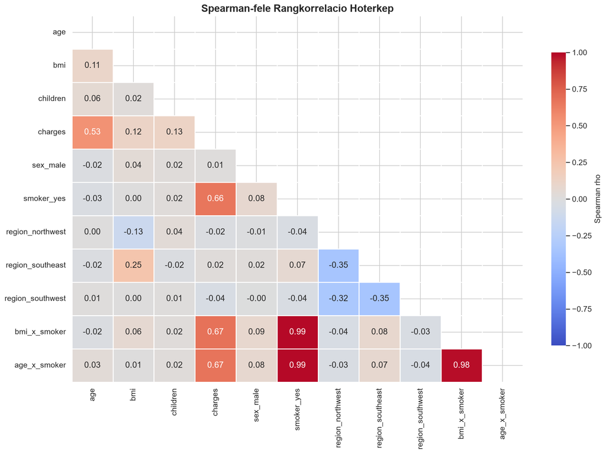

🔍 Nagyítás kattintással

**Magyarázat:** Spearman rangkorrelációs hőtérkép. Mivel a célváltozó ferde eloszlású és nemlineáris küszöbhatások vannak, a Spearman korreláció jóval megbízhatóbb, mint a Pearson. A célváltozóval a legerősebb kapcsolatot a smoker_yes (rho = 0.66), a bmi_x_smoker (rho = 0.67) és az age (rho = 0.53) mutatja.

05

## 5. Multikollinearitás és Variancia Inflációs Faktor (VIF) Vizsgálata

A többváltozós regresszióban elengedhetetlen a magyarázó változók közötti káros együttmozgás (multikollinearitás) kiszűrése. A túlzott multikollinearitás destabilizálja az OLS becsléseket, torzítja a konfidencia-intervallumokat és felrobbantja a standard hibákat. A vizsgálatot szigorú, kétlépcsős ökonometriai eljárással végeztük el: először páronkénti Spearman-korreláció szűréssel (|ρ| > 0.7), majd a fennmaradó magyarázó változókra konstanssal kiegészített VIF (Variance Inflation Factor) elemzést hajtottunk végre.

**5. Fejezet Kódjának Megtekintése (Páronkénti szűrés és VIF)**

```python
# 4.1 - Magas korrelacio szurese a magyarazo valtozok kozott (|rho| > 0.7)
corr_X = df_encoded[X_cols].corr(method="spearman")
dropped_corr = []

for i in range(len(X_cols)):
    for j in range(i + 1, len(X_cols)):
        var1, var2 = X_cols[i], X_cols[j]
        corr_val = abs(corr_X.loc[var1, var2])
        if corr_val > 0.7:
            corr_y_var1 = abs(spearman_corr.loc[var1, target])
            corr_y_var2 = abs(spearman_corr.loc[var2, target])
            to_drop = var1 if corr_y_var1 < corr_y_var2 else var2
            if to_drop not in dropped_corr:
                dropped_corr.append(to_drop)

# 4.2 - VIF szamitas konstanssal
def calculate_vif(X_data):
    X_const = sm.add_constant(X_data)
    vif_data = pd.DataFrame()
    vif_data["Valtozo"] = X_const.columns
    vif_data["VIF"] = [variance_inflation_factor(X_const.values, i)
                       for i in range(X_const.shape[1])]
    return vif_data

# Iterativ VIF szures VIF > 5.0 eseten
while True:
    vif_df = calculate_vif(X_vif)
    vif_no_const = vif_df[vif_df["Valtozo"] != "const"]
    if vif_no_const["VIF"].max() > 5.0:
        X_vif = X_vif.drop(columns=[vif_no_const.loc[vif_no_const["VIF"].idxmax(), "Valtozo"]])
    else:
        break
```

⚠️ 5.1 Páronkénti Korrelációs Szűrés (|ρ| > 0.7) — Kiszűrt Változók:

A magyarázó változók Spearman-féle korrelációs mátrixának vizsgálatakor két változópárnál tapasztaltunk kritikus mértékű, a 0.7-es küszöbértéket jóval meghaladó együttmozgást. Az információs veszteség minimalizálása érdekében azt a tagot ejtettük ki, amelyik gyengébben korrelált a célváltozóval (`charges`):

- **`smoker_yes` → KISZŰRVE:**  
  Szinte determinisztikus, kollineáris kapcsolat állt fenn a `bmi_x_smoker` interakciós taggal (**|ρ| = 0.9913 > 0.7**). Mivel a célváltozóval a `bmi_x_smoker` szorosabb kapcsolatot mutatott (ρ = 0.6721, szemben a `smoker_yes` ρ = 0.6636 értékével), a szabályrendszerünk szerint a **`smoker_yes` változót zártuk ki**.
- **`age_x_smoker` → KISZŰRVE:**  
  Szintén extrém erős összefüggést mutatott a `bmi_x_smoker` taggal (**|ρ| = 0.9837 > 0.7**). A célváltozóval mért magyarázóerő alapján (ρ = 0.6721 vs. ρ = 0.6651) a `bmi_x_smoker` maradt bent a modellben, így az **`age_x_smoker` változót szűrtük ki**.

📌 **Összegzés:**  
• **Kiszűrt változók (2 db):** `['smoker_yes', 'age_x_smoker']`  
• **Továbbjutó magyarázó változók a VIF vizsgálathoz (8 db):** `['age', 'bmi', 'children', 'sex_male', 'region_northwest', 'region_southeast', 'region_southwest', 'bmi_x_smoker']`

### 5.2 Variancia Inflációs Faktor (VIF) Eredménytáblázat (n = 1 337)

A VIF (Variance Inflation Factor) azt méri, hogy egy magyarázó változó varianciája hányszorosára növekszik a többi változóval való lineáris összefüggése miatt. Az ökonometriai gyakorlatban a **VIF > 5.0** (konzervatív) vagy **VIF > 10.0** érték jelez veszélyes multikollinearitást.

| Magyarázó Változó | VIF Érték | Tolerancia (1/VIF) | Multikollinearitás Állapota |
| --- | --- | --- | --- |
| `age` | 1.02 | 0.983 | ✅ Elfogadható (VIF < 5.0, nincs multikollinearitás) |
| `bmi` | 1.11 | 0.897 | ✅ Elfogadható (VIF < 5.0, nincs multikollinearitás) |
| `children` | 1.00 | 0.996 | ✅ Elfogadható (VIF < 5.0, nincs multikollinearitás) |
| `sex_male` | 1.01 | 0.990 | ✅ Elfogadható (VIF < 5.0, nincs multikollinearitás) |
| `region_northwest` | 1.52 | 0.659 | ✅ Elfogadható (VIF < 5.0, nincs multikollinearitás) |
| `region_southeast` | 1.65 | 0.605 | ✅ Elfogadható (VIF < 5.0, nincs multikollinearitás) |
| `region_southwest` | 1.53 | 0.654 | ✅ Elfogadható (VIF < 5.0, nincs multikollinearitás) |
| `bmi_x_smoker` | 1.03 | 0.975 | ✅ Elfogadható (VIF < 5.0, nincs multikollinearitás) |

✅ VIF Eredmény: Teljesen Megszűnt a Multikollinearitás!

A fenti táblázat tanúsága szerint valamennyi megmaradt magyarázó változó VIF értéke **1.00 és 1.65 között alakult**, ami messze alatta marad a szigorú 5.0-s határértéknek. A legmagasabb VIF a `region_southeast` változónál adódott (1.65), ami a területi dummy kódolás természetes sajátossága. **Az iteratív VIF-szűrés során további változót már nem kellett kizárni**, a modell információ-mátrixa stabil és jól kondicionált maradt.

06

## 6. Változószelekció: Automatizált Backward Elimination (Hátrafelé Elimináció)

A felesleges, nem szignifikáns változók eltávolítására automatizált, lépésről lépésre naplózott hátrafelé eliminációt alkalmaztunk `α = 0.05` szignifikanciaszint mellett.

**6. Fejezet Kódjának Megtekintése (Backward Elimination Ciklus)**

```python
alpha = 0.05
be_cols = X_cols_final.copy()
step = 0

while True:
    step += 1
    X_be = sm.add_constant(df_encoded[be_cols])
    model_be = sm.OLS(y, X_be).fit()
    pvalues = model_be.pvalues.drop("const") # const soha nem eshet ki
    max_pval = pvalues.max()
    max_pval_var = pvalues.idxmax()

    if max_pval > alpha:
        be_cols.remove(max_pval_var)
    else:
        break # Minden valtozo szignifikans
```

### A Hátrafelé Elimináció Iterációs Története

| Iteráció | Kiszűrt változó | p-érték | Modell Adj. R² | Fennmaradó változók |
| --- | --- | --- | --- | --- |
| #1 | `region_northwest` | 0.25639 | 0.821351 | 7 |
| #2 | `sex_male` | 0.17325 | 0.821312 | 6 |
| #3 | `Nincs (Minden p <= 0.05)` | 0.01411 | 0.821197 | 6 |

07

## 7. A Végső OLS Modell Értékelése és Gyakorlati Üzleti Interpretációja ($)

A végső modell illeszkedése kiemelkedő: a magyarázóerő az interakció révén **74.95%-ról 82.20%-ra** emelkedett, miközben az átlagos becslési hiba (RMSE) közel 1 000 dollárral csökkent.

**7. Fejezet Kódjának Megtekintése (Végső OLS és Modell-összehasonlítás)**

```python
X_final = sm.add_constant(df_encoded[be_cols])
ols_final = sm.OLS(y, X_final).fit()

final_rmse = np.sqrt(mean_squared_error(y, ols_final.predict(X_final)))
final_mae = mean_absolute_error(y, ols_final.predict(X_final))
print(ols_final.summary())
```

### Alapmodell (8 változó) vs. Végső Modell (6 változó) Összehasonlítása

| Mutato | Alapmodell (5. pont) | Vegso modell (BE, 6. pont) |
| --- | --- | --- |
| R2 | 0.822421 | 0.822000 |
| Adj. R2 | 0.821351 | 0.821197 |
| F-statisztika | 768.80 | 1023.65 |
| AIC | 26640.91 | 26640.07 |
| BIC | 26687.69 | 26676.46 |
| RMSE | 5101.41 | 5107.45 |
| MAE | 3133.38 | 3136.79 |
| Valtozok szama | 8 | 6 |

### A Végső OLS Modell Regressziós Együtthatói (Egész Dollárra Kerekítve)

Az alábbi táblázatban az együtthatók, hibák és konfidencia-intervallumok egész dollárokra kerekítve szerepelnek a közvetlen gyakorlati értelmezhetőség céljából.

| Változó | Koefficiens ($) | Std. Hiba (SE) | t-érték | p-érték (P>\|t\|) | 95% CI Alsó | 95% CI Felső |
| --- | --- | --- | --- | --- | --- | --- |
| `const` | -$7 091 | $798 | -9 | < 0.0001 | -$8 657 | -$5 525 |
| `age` | $261 | $10 | 26 | < 0.0001 | $242 | $281 |
| `bmi` | $163 | $24 | 7 | < 0.0001 | $115 | $210 |
| `children` | $488 | $116 | 4 | < 0.0001 | $260 | $717 |
| `region_southeast` | -$942 | $351 | -3 | 0.0074 | -$1 631 | -$254 |
| `region_southwest` | -$860 | $350 | -2 | 0.0141 | -$1 546 | -$173 |
| `bmi_x_smoker` | $803 | $11 | 72 | < 0.0001 | $781 | $825 |

A Végső Ökonometriai Regressziós Egyenlet (Egész Számokra Kerekítve):

charges = -7 091 + (261 × age) + (163 × bmi) + (488 × children) - (942 × region_se) - (860 × region_sw) + (803 × bmi_x_smoker)

### Gyakorlati, Dollárban Kifejezett Üzleti Interpretáció

💰 Életkor (age): +$261 / év

Minden megélt életév egyéb tényezők változatlansága mellett (ceteris paribus) átlagosan **+$261 összeggel növeli az éves biztosítási terhet**. Egy 50 éves személy egy 20 éves fiatalhoz képest (30 év korkülönbség) pusztán a kora miatt átlagosan `30 × $261 =` **+$7 830 többletkiadást** generál évente a biztosítónak.

👶 Eltartott Gyermekek (children): +$488 / gyermek

Minden egyes biztosított gyermek átlagosan **+$488 összeggel növeli** a család éves ellátási költségeit.

🗺️ Régiók: Southeast (-$942) és Southwest (-$860)

Az északkeleti referencia-régióhoz képest a déli államokban az egészségügyi árszínvonal és az ellátási díj átlagosan **$860 - $942 összeggel alacsonyabb**.

🔥 A KULCSMEGÁLLAPÍTÁS: A BMI és a Dohányzás Kölcsönhatása (bmi_x_smoker: +$803)

*A dohányzás nem egyszerűen egy fix összegű pluszköltséget jelent, hanem a BMI-vel arányosan növeli a biztosítási költségeket. Egy dohányzó személy esetén minden egyes egységnyi BMI növekedés +803 USD extra költséget generál — a magas BMI-jű dohányzók tehát exponenciálisan drágábbak a biztosító számára!*

- **Nem dohányzó személy esetén:** 1 pont BMI növekedés költséghatása: **+$163 / év**.
- **Dohányzó személy esetén:** 1 pont BMI növekedés költséghatása: `$163 + $803 =` **+$966 / év**!

**Számpélda egy 13 pontos BMI növekedésre (normál testsúlyról elhízásra: 22 → 35 kg/m²):**  
• **Ha NEM dohányzik:** Költségnövekedése: `13 × $163 =` **+$2 119 / év**.  
• **Ha DOHÁNYZIK:** Ugyanez a testsúlygyarapodás: `13 × $966 =` **+$12 558 / év** többletkiadást eredményez!  
**Konklúzió: A dohányzás közel HATSZOROSÁRA (5.93×) sokszorozza fel a túlsúlyból fakadó ellátási költségterhet!**

⚖️ Változó-Fontosság & Hatásnagyság

### 7.2 Standardizált OLS Modell – A Változók Relatív Hatásának Elemzése (Standardizált Béták)

A nyers regressziós együtthatók közvetlenül **nem alkalmasak a változók fontosságának összehasonlítására**, mivel eltérő mértékegységekben mérjük őket (évek, kg/m², gyermekek darabszáma, vagy 0/1 dummy indikátorok). A magyarázó változók standardizálásával (átlag = 0, szórás = 1) a kapott **standardizált béták (β*)** dimenziómentes skálára kerülnek, és közvetlenül mutatják meg, hogy **melyik tényező gyakorolja a legnagyobb relatív hatást az egészségügyi költségekre**.

**7.2 Kód: Változók Standardizálása és Standardizált OLS Modell Illesztése**

```python
from sklearn.preprocessing import StandardScaler

# Magyarázó változók és célváltozó standardizálása (z-score)
scaler_X = StandardScaler()
X_final_std = pd.DataFrame(scaler_X.fit_transform(df_encoded[be_cols]), columns=be_cols)
y_std = (y - y.mean()) / y.std(ddof=1)

# Standardizált OLS regressziós modell illesztése konstanssal
ols_std = sm.OLS(y_std, sm.add_constant(X_final_std)).fit()
print(ols_std.summary())
```

📊 ÁBRA 12. Ábra: Standardizált Regressziós Koefficiensek (β*) és Változó-fontossági Rangsor

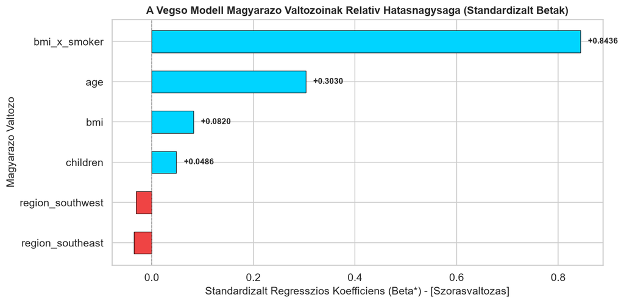

🔍 Nagyítás kattintással

**Magyarázat:** A végső modell magyarázó változóinak relatív hatásnagysága (standardizált béták). A bmi_x_smoker interakciós tag magasan a legdominánsabb tényező (béta = +0.8436), ezt követi az életkor (béta = +0.3030), míg a BMI önálló hatása (béta = +0.0820), a gyermekek száma (+0.0486) és a regionális különbségek (-0.035, -0.030) jóval kisebb relatív súllyal bírnak.

### Standardizált Béták és 1 Szórásnyi Hatások Táblázata

| Rangsor | Magyarázó Változó | Nyers Béta ($) | Változó Szórása (SD) | Standardizált Béta (β*) | 1 SD Hatás ($) | p-érték | Relatív Hatás / Szerep |
| --- | --- | --- | --- | --- | --- | --- | --- |
| #1 | `bmi_x_smoker` | $803 | 12.72 | +0.8436 | +$10 220 | < 0.0001 | 🔥 Kiemelkedően domináns költségnövelő (első számú tényező) |
| #2 | `age` | $261 | 14.04 | +0.3030 | +$3 671 | < 0.0001 | 📈 Erős biológiai költségnövelő faktor (második legfontosabb) |
| #3 | `bmi` | $163 | 6.10 | +0.0820 | +$993 | < 0.0001 | ⚖️ Mérsékelt önálló növelő hatás (nem dohányzóknál) |
| #4 | `children` | $488 | 1.21 | +0.0486 | +$589 | < 0.0001 | 👶 Kis mértékű, de szignifikáns többletköltség |
| #5 | `region_southeast` | -$942 | 0.45 | -0.0346 | -$420 | 0.0074 | 🗺️ Enyhe regionális díjkedvezmény (Southeast) |
| #6 | `region_southwest` | -$860 | 0.43 | -0.0304 | -$369 | 0.0141 | 🗺️ Enyhe regionális díjkedvezmény (Southwest) |

📊 Mit Árulnak el a Standardizált Béták az Üzleti és Kockázati Döntéshozónak?

- **#1 Helyezett — `bmi_x_smoker` (β* = +0.8436):**  
  Az elhízás és a dohányzás szinergikus kölcsönhatása toronymagasan a legfontosabb költséggenerátor a biztosítási portfólióban. 1 szórásnyi növekedése (12.72 pont) **+$10 220 többletköltséget** okoz! Relatív hatása közel **háromszor akkora**, mint a második helyezett életkoré.
- **#2 Helyezett — `age` (β* = +0.3030):**  
  A biológiai életkor a második legfontosabb költségtényező: 1 szórásnyi korkülönbség (14.04 év) átlagosan **+$3 671 többletkiadással** jár az ügyfél felett.
- **#3 Helyezett — `bmi` (β* = +0.0820):**  
  A nem dohányzók esetén a testsúly önálló szerepe számottevően visszafogottabb (1 szórás = 6.10 BMI pont → +$993 / év). Ez igazolja az aktuáriusok számára, hogy a normál túlsúly önmagában csak mérsékelt kockázat — a valódi robbanást a dohányzással való kombináció okozza.
- **#4 Helyezett — `children` (β* = +0.0486):**  
  A gyermekek száma kiszámítható, szignifikáns, de kisebb súlyú költségtényező (1 szórás = 1.21 gyermek → +$589 / év).
- **#5–6 Helyezettek — `region_southeast` (β* = -0.0346) és `region_southwest` (β* = -0.0304):**  
  Bár statisztikailag szignifikánsak, hatásuk relatív nagyságrendje marginális (mintegy 25-ször gyengébb a dohányzás-BMI hatásánál).

08

## 8. OLS Diagnosztikai Vizsgálatok és HC3 Robusztus Standard Hibák

A lineáris modell klasszikus feltevéseit szigorú ökonometriai tesztekkel vetettük össze: a hibatagok normalitását, a homoszkedaszticitást, az autokorrelációt és a kiugró adatpontok befolyását.

**8. Fejezet Kódjának Megtekintése (Diagnosztika és HC3 Robusztus Becslés)**

```python
# Normalitas: Shapiro-Wilk es Jarque-Bera
sw_stat, sw_pval = shapiro(residuals)
jb_stat, jb_pval = jarque_bera(residuals)

# Homoszkedaszticitas: Breusch-Pagan teszt
bp_stat, bp_pval, bp_fstat, bp_fpval = het_breuschpagan(residuals, X_final)

# Autokorrelacio: Durbin-Watson
dw_stat = durbin_watson(residuals)

# Cook-tavolsag (4/n kuszobertek)
cooks_d = ols_final.get_influence().cooks_distance[0]
cooks_threshold = 4 / len(y)

# HC3 Robusztus standard hibak
ols_robust = sm.OLS(y, X_final).fit(cov_type="HC3")
```

### 8.1 Hibatagok Normalitása

📊 ÁBRA 13. Ábra: Reziduálisok Normalitása (Hisztogram és Normal Q-Q Plot)

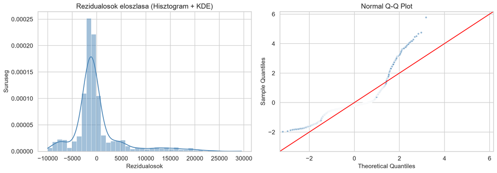

🔍 Nagyítás kattintással

**Magyarázat:** Bal oldal: A reziduálisok hisztogramja és KDE görbéje pozitív ferdeséget mutat. Jobb oldal: A Normal Q-Q ploton a felső kvantilisek élesen felfelé ívelnek, ami a ritka, nagyértékű orvosi beavatkozások vastag farkát (heavy tail) bizonyítja.

⚠️ Normalitási Tesztek: H₀ Elutasítva

Shapiro–Wilk p = 0.000000 (p < 0.0001), Jarque–Bera p = 0.000000 (p < 0.0001). A reziduálisok nem normálisak, ami az egészségügyi adatok aszimmetrikus kárkifizetései miatt természetes. Nagy mintánál (n = 1 337) a **Centrális Határeloszlás-tétel (CLT)** garantálja az OLS becslések aszimptotikus torzítatlanságát.

### 8.2 Homoszkedaszticitás Vizsgálata

📊 ÁBRA 14. Ábra: Reziduálisok vs. Becsült Értékek (LOESS Trendvonallal)

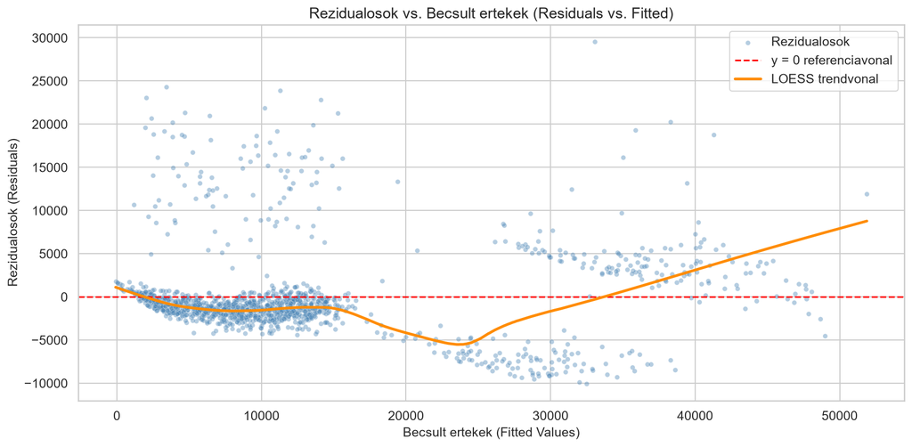

🔍 Nagyítás kattintással

🚨 Breusch–Pagan-teszt: Heteroszkedaszticitás Jelenléte

LM-statisztika = 18.1560 (p = 0.00585 < 0.01). A hibavariancia nem konstans, ezért elengedhetetlen a robusztus standard hibák alkalmazása.

### 8.3 Autokorreláció és Függetlenség

✅ Durbin–Watson Statisztika: 2.1019

A DW érték (2.1019) tökéletesen az 1.5–2.5 közötti ideális sávban van, keresztmetszeti adatoknál a megfigyelések függetlenek.

### 8.4 Kiugró és Befolyásos Pontok (Cook's Distance)

📊 ÁBRA 15. Ábra: Cook-féle Távolságok Megfigyelésenként

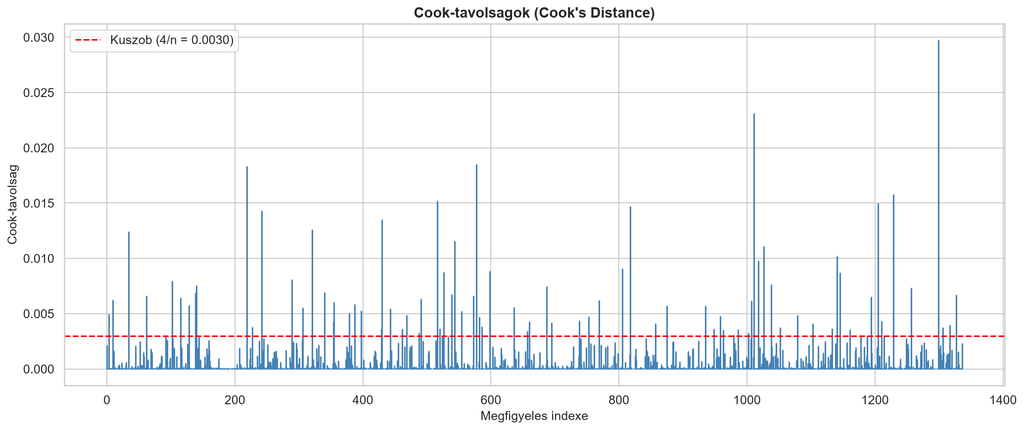

🔍 Nagyítás kattintással

**Magyarázat:** Cook-féle távolságok diagramja. A piros szaggatott vonal a 4/n = 0.002992 kritikus küszöbértéket jelöli. Bár a pontok 6.0%-a meghaladja a küszöböt, a legmagasabb Cook-távolság mindössze 0.0297, ami messze elmarad az 0.5 vagy 1.0 kritikus szinttől.

### Top 10 Legbefolyásosabb Megfigyelés

| Helyezés | Megfigyelés Indexe | Cook-távolság | Életkor | BMI | Dohányzó? | Tényleges Költség ($) |
| --- | --- | --- | --- | --- | --- | --- |
| #1 | 1 299 | 0.029730 | 45 | 30.36 | yes | $62 593 |
| #2 | 1 011 | 0.023104 | 61 | 33.33 | no | $36 580 |
| #3 | 577 | 0.018505 | 31 | 38.09 | yes | $58 571 |
| #4 | 219 | 0.018348 | 24 | 23.21 | no | $25 082 |
| #5 | 1 229 | 0.015760 | 52 | 34.48 | yes | $60 021 |
| #6 | 516 | 0.015205 | 20 | 35.31 | no | $27 724 |
| #7 | 1 205 | 0.014991 | 59 | 34.80 | no | $36 911 |
| #8 | 818 | 0.014699 | 33 | 35.53 | yes | $55 135 |
| #9 | 242 | 0.014304 | 55 | 26.80 | no | $35 160 |
| #10 | 430 | 0.013512 | 19 | 33.10 | no | $23 083 |

### 8.5 HC3 Robusztus Standard Hibák (White-féle Korrekció)

A heteroszkedaszticitás orvoslására MacKinnon & White (1985) HC3 típusú robusztus kovarianciamátrixát használtuk.

| Változó | Koefficiens ($) | Hagyományos OLS SE | HC3 Robusztus SE | SE Változás (%) | Hagyományos p | HC3 Robusztus p | Szignifikancia |
| --- | --- | --- | --- | --- | --- | --- | --- |
| `const` | -$7 091 | $798 | $754 | -5.5% | < 0.0001 | < 0.0001 | Erősen szignifikáns (p < 0.001) |
| `age` | $261 | $10 | $10 | +1.1% | < 0.0001 | < 0.0001 | Erősen szignifikáns (p < 0.001) |
| `bmi` | $163 | $24 | $23 | -3.9% | < 0.0001 | < 0.0001 | Erősen szignifikáns (p < 0.001) |
| `children` | $488 | $116 | $110 | -5.7% | < 0.0001 | < 0.0001 | Erősen szignifikáns (p < 0.001) |
| `region_southeast` | -$942 | $351 | $375 | +6.7% | 0.0074 | 0.0119 | Szignifikáns (p < 0.05) |
| `region_southwest` | -$860 | $350 | $335 | -4.2% | 0.0141 | 0.0103 | Szignifikáns (p < 0.05) |
| `bmi_x_smoker` | $803 | $11 | $13 | +17.7% | < 0.0001 | < 0.0001 | Erősen szignifikáns (p < 0.001) |

09

## 9. Stratégiai Vezetői Összefoglaló és Üzleti Ajánlások

Az elemzés alapján az alábbi konkrét üzleti és termékfejlesztési döntéseket javasoljuk az egészségbiztosítók számára:

1. Interakciós Díjszabási Rendszer

Meg kell szüntetni a dohányzásra kivetett fix pótdíjat. A díjszabási algoritmusnak a **BMI × dohányzás szorzatot** kell beáraznia, mert a túlsúlyos dohányzók költségkockázata exponenciálisan magasabb.

2. Magas Megtérülésű (ROI) Wellness Programok

Mivel a dohányzó elhízottaknál minden leadott BMI pont **évi $966 közvetlen megtakarítást** jelent a biztosítónak, a dohányzásleszoktató terápiák és dietetikai tanácsadások finanszírozása azonnali, kiemelkedő pénzügyi megtérülést hoz.

3. Tartalékképzés a Jobb Farok Kezelésére

A normalitás hiánya és a vastag jobboldali farok miatt a biztosítónak a ritka, extrém költségű kárkifizetésekre katasztrófa-kockázati tőketartalékot és viszontbiztosítási (reinsurance) védelmet kell fenntartania.

4. Kiszámítható Családi és Korcsoportos Csomagok

Az életkor évenkénti +$261-os és a gyermekek darabonkénti +$488-os stabil hatása átlátható, versenypiaci alapot nyújt a családi és szenior csomagok differenciált kialakításához.